# Heart Diseases

Michał Szelezin

## `Plik źródłowy`

[Link do Kaggle.com](https://www.kaggle.com/datasets/neurocipher/heartdisease?resource=download)

# `1.Wstęp`

Obiektem dzisiejszej analizy, będzie plik z wynikami medycznymi oraz danymi na temat stylu życia pacjentów w celu oszacowania ryzyka chorób serca. Dzięki tym informacjom postaram się uzyskać odpowiedzi na następujące pytania:

1. Czy istnieje zależność pomiędzy wiekiem oraz płcią pacjentów, a prawdopodobieństwem wystąpienia choroby serca?
2. Które badania mają największą korelacje między konkretnymi wynikami a istnieniem choroby serca?
3. Czy istnieje korelacja pomiędzy konkretnymi badaniami?

# `2.Omówienie danych`

Plik źródłowy zawiera dane dla następujących kategorii:

- **Wiek** - *Age*
- **Płeć** - *Sex*
  - 1 - mężczyzna
  - 0 - kobieta
- **Typ bólu serca** - *Chest.pain.type*
  - 1 - typowy dławicowy
  - 2 - atypowy dławicowy
  - 3 - ból nieprzypominający dławicy
  - 4 - bez bólu
- **Ciśnienie tętnicze w spoczynku** - *BP*
- **Poziom cholesterolu** - *Cholesterol*
- **Poziom glukozy na czczo** - *FBS.over.120*
  - 1 - wysoki
  - 0 - niski
- **Wynik EKG w spoczynku** - *EKG.results*
  - 0 - prawidłowy zapis
  - 1 - nieprawidłowości w zapisie typu przerost
  - 2 - inne nieprawidłowości w zapisie
- **Maksymalne tętno** - *Max.HR*
- **Dławica piersiowa wysiłkowa** - *Exercise.angina*
  - 1 - występuje
  - 0 - brak występowania
- **Wartość obniżenie odcinka ST** - *ST.depression*
  - 0.0 - brak obniżenie
  - 01.-1.0 - niewielkie obniżenie
  - >1.0 - istotne obniżenie
- **Kategoria nachylenia odcinka ST** - *Slope.of.ST*
  - 1 - ST rosnący
  - 2 - ST płaski
  - 3 - ST opadający
- **Liczba głównych naczyń wieńcowych** - *Number.of.vessels.fluro*
  - 0 - brak widocznych zwężeń
  - 1 - jedno naczynie z widoczną zmianą
  - 2 - dwa naczynia z widoczną zmianą
  - 3 - trzy naczynia z widoczną zmianą
- **Wynik testu obciążeniowego(scyntygrafia serca)** - *Thallium*
  - 3 - normalny przepływ
  - 6 - defekt stały
  - 7 - defekt odwracalny
- **Istniejące choroby serca** - *Heart.Disease*
  - Presence - istnieje choroba serca
  - Absence - brak występowania choroby serca

```r
dane<-read.csv("Heart_Disease_Prediction.csv")
head(dane,5)
```

```
##   Age Sex Chest.pain.type  BP Cholesterol FBS.over.120 EKG.results Max.HR
## 1  70   1               4 130         322            0           2    109
## 2  67   0               3 115         564            0           2    160
## 3  57   1               2 124         261            0           0    141
## 4  64   1               4 128         263            0           0    105
## 5  74   0               2 120         269            0           2    121
##   Exercise.angina ST.depression Slope.of.ST Number.of.vessels.fluro Thallium
## 1               0           2.4           2                       3        3
## 2               0           1.6           2                       0        7
## 3               0           0.3           1                       0        7
## 4               1           0.2           2                       1        7
## 5               1           0.2           1                       1        3
##   Heart.Disease
## 1      Presence
## 2       Absence
## 3      Presence
## 4       Absence
## 5       Absence
```

```r
tail(dane,5)
```

```
##     Age Sex Chest.pain.type  BP Cholesterol FBS.over.120 EKG.results Max.HR
## 266  52   1               3 172         199            1           0    162
## 267  44   1               2 120         263            0           0    173
## 268  56   0               2 140         294            0           2    153
## 269  57   1               4 140         192            0           0    148
## 270  67   1               4 160         286            0           2    108
##     Exercise.angina ST.depression Slope.of.ST Number.of.vessels.fluro Thallium
## 266               0           0.5           1                       0        7
## 267               0           0.0           1                       0        7
## 268               0           1.3           2                       0        3
## 269               0           0.4           2                       0        6
## 270               1           1.5           2                       3        3
##     Heart.Disease
## 266       Absence
## 267       Absence
## 268       Absence
## 269       Absence
## 270      Presence
```

# `3. Uporządkowanie danych`

```r
summarise(dane, across(everything(), ~sum(is.na(.))))
```

```
##   Age Sex Chest.pain.type BP Cholesterol FBS.over.120 EKG.results Max.HR
## 1   0   0               0  0           0            0           0      0
##   Exercise.angina ST.depression Slope.of.ST Number.of.vessels.fluro Thallium
## 1               0             0           0                       0        0
##   Heart.Disease
## 1             0
```

```r
dane <- arrange(dane, desc(Age))
head(dane, 10)
```

```
##    Age Sex Chest.pain.type  BP Cholesterol FBS.over.120 EKG.results Max.HR
## 1   77   1               4 125         304            0           2    162
## 2   76   0               3 140         197            0           1    116
## 3   74   0               2 120         269            0           2    121
## 4   71   0               4 112         149            0           0    125
## 5   71   0               3 110         265            1           2    130
## 6   71   0               2 160         302            0           0    162
## 7   70   1               4 130         322            0           2    109
## 8   70   1               2 156         245            0           2    143
## 9   70   1               3 160         269            0           0    112
## 10  70   1               4 145         174            0           0    125
##    Exercise.angina ST.depression Slope.of.ST Number.of.vessels.fluro Thallium
## 1                1           0.0           1                       3        3
## 2                0           1.1           2                       0        3
## 3                1           0.2           1                       1        3
```

[output cut: 18 more lines]

Możemy zauważyć, że nie występują żadne braki w wierszach, a zmienne uporządkowaliśmy malejąco wg wieku pacjentów. Wartości w poszczególnych kategoriach wydają się wiarygodne dla podanego przez mnie opisu, a przydatność konkretnych zmiennych będziemy sprawdzać w trakcie dalszej pracy, wstępnie wszystkie dane mają potencjalną wartość dla naszej analizy.

Przygotuję dwie nowe tabele rodzielające osoby z chorobą oraz bez choroby serca, które mogą potencjalnie się przydać w dalszych rozważaniach

```r
dane_bez <- filter(dane, Heart.Disease=="Absence")
head(dane_bez,5)
```

```
##   Age Sex Chest.pain.type  BP Cholesterol FBS.over.120 EKG.results Max.HR
## 1  76   0               3 140         197            0           1    116
## 2  74   0               2 120         269            0           2    121
## 3  71   0               4 112         149            0           0    125
## 4  71   0               3 110         265            1           2    130
## 5  71   0               2 160         302            0           0    162
##   Exercise.angina ST.depression Slope.of.ST Number.of.vessels.fluro Thallium
## 1               0           1.1           2                       0        3
## 2               1           0.2           1                       1        3
## 3               0           1.6           2                       0        3
## 4               0           0.0           1                       1        3
## 5               0           0.4           1                       2        3
##   Heart.Disease
## 1       Absence
## 2       Absence
## 3       Absence
## 4       Absence
## 5       Absence
```

```r
dane_cho <- filter(dane, Heart.Disease=="Presence")
head(dane_cho,5)
```

```
##   Age Sex Chest.pain.type  BP Cholesterol FBS.over.120 EKG.results Max.HR
## 1  77   1               4 125         304            0           2    162
## 2  70   1               4 130         322            0           2    109
## 3  70   1               3 160         269            0           0    112
## 4  70   1               4 145         174            0           0    125
## 5  69   1               3 140         254            0           2    146
##   Exercise.angina ST.depression Slope.of.ST Number.of.vessels.fluro Thallium
## 1               1           0.0           1                       3        3
## 2               0           2.4           2                       3        3
## 3               1           2.9           2                       1        7
## 4               1           2.6           3                       0        7
## 5               0           2.0           2                       3        7
##   Heart.Disease
## 1      Presence
## 2      Presence
## 3      Presence
## 4      Presence
## 5      Presence
```

# `4. Wiek, płeć oraz występowanie choroby serca`

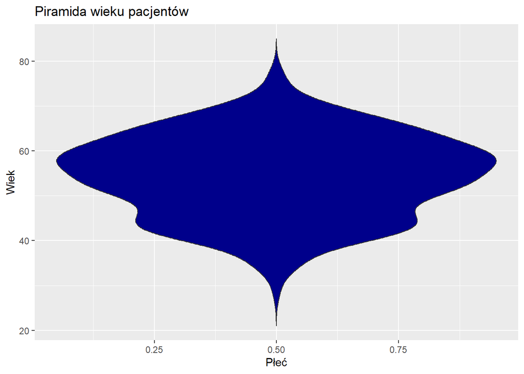

```r
ggplot(data = dane, aes(x = Sex, y = Age))+
  geom_violin(fill = "darkblue", trim=FALSE)+
  labs(
    title="Piramida wieku pacjentów",
    x="Płeć",
    y="Wiek"
  )
```

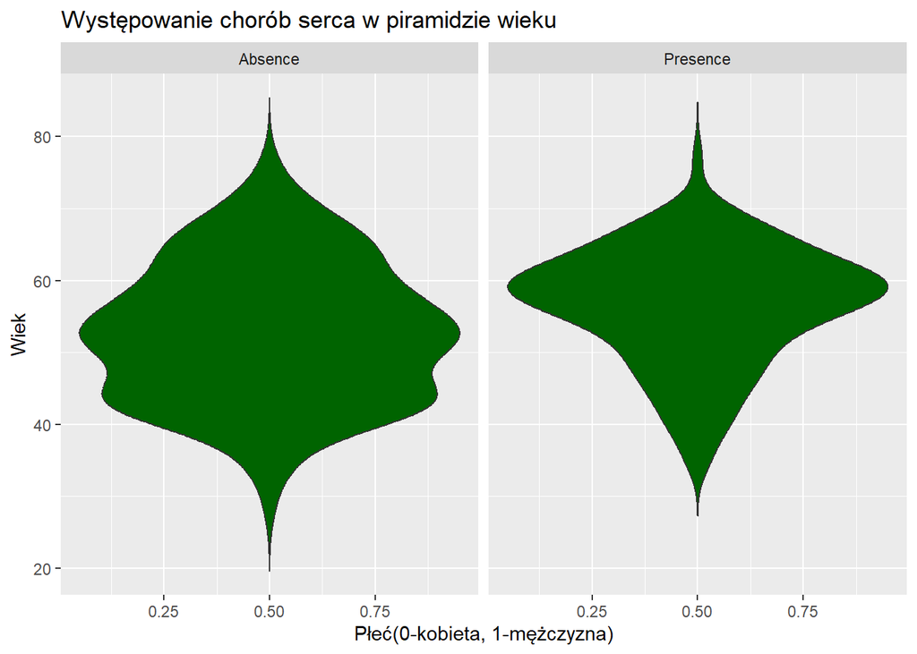

```r
ggplot(data = dane, aes(x = Sex, y = Age))+
  geom_violin(fill = "darkgreen", trim=FALSE)+
  facet_wrap(~ Heart.Disease)+
  labs(
    title="Występowanie chorób serca w piramidzie wieku",
    x="Płeć(0-kobieta, 1-mężczyzna)",
    y="Wiek"
  )
```

Z wykresu jesteśmy w stanie wywnioskować, że istnieje pewna zależność między wiekiem, a częstotliwością występowania, czyli:

- wraz z wiekiem rośnie prawdopodobieństwo na rozwinięcie choroby serca
- po osiągnięciu wieku 60 lat drastycznie spada prawdopodobieństwo rozwinięcie choroby jeśli wcześniej nie wystąpiła
- na okolice wieku 50 lat przypada punkt krytyczny przed nagłym wzrostem ryzyka rozwinięcia choroby serca

Korelacja występuje tylko pomiędzy dwiema zmiennymi liniowymi, nie kategorycznymi, więc wszystkie te wnioski są jedynie zależnościa, a nie korelacją, ze względu na charakter badanych zmiennych.

# `5. Histogramy dla zmiennych numerycznych`

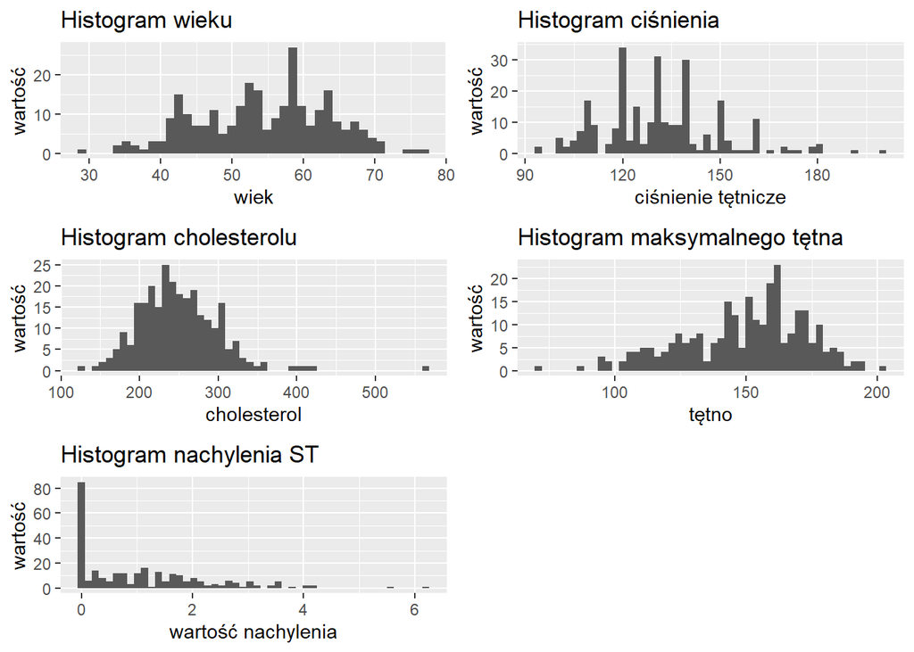

```r
h1 <- ggplot(dane, aes(x=Age)) +geom_histogram(bins=40) +labs(title="Histogram wieku",x="wiek",y="wartość")

h2 <- ggplot(dane, aes(x=BP)) +geom_histogram(bins=50) +labs(title="Histogram ciśnienia",x="ciśnienie tętnicze",y="wartość")

h3 <- ggplot(dane, aes(x=Cholesterol)) +geom_histogram(bins=50) +labs(title="Histogram cholesterolu",x="cholesterol",y="wartość")

h4 <- ggplot(dane, aes(x=Max.HR)) +geom_histogram(bins=50) +labs(title="Histogram maksymalnego tętna",x="tętno",y="wartość")

h5 <- ggplot(dane, aes(x=ST.depression)) +geom_histogram(bins=50) +labs(title="Histogram nachylenia ST",x="wartość nachylenia",y="wartość")

grid.arrange(h1,h2,h3,h4,h5, ncol=2)
```

# `6. Wykresy dla zmiennych kategorycznych`

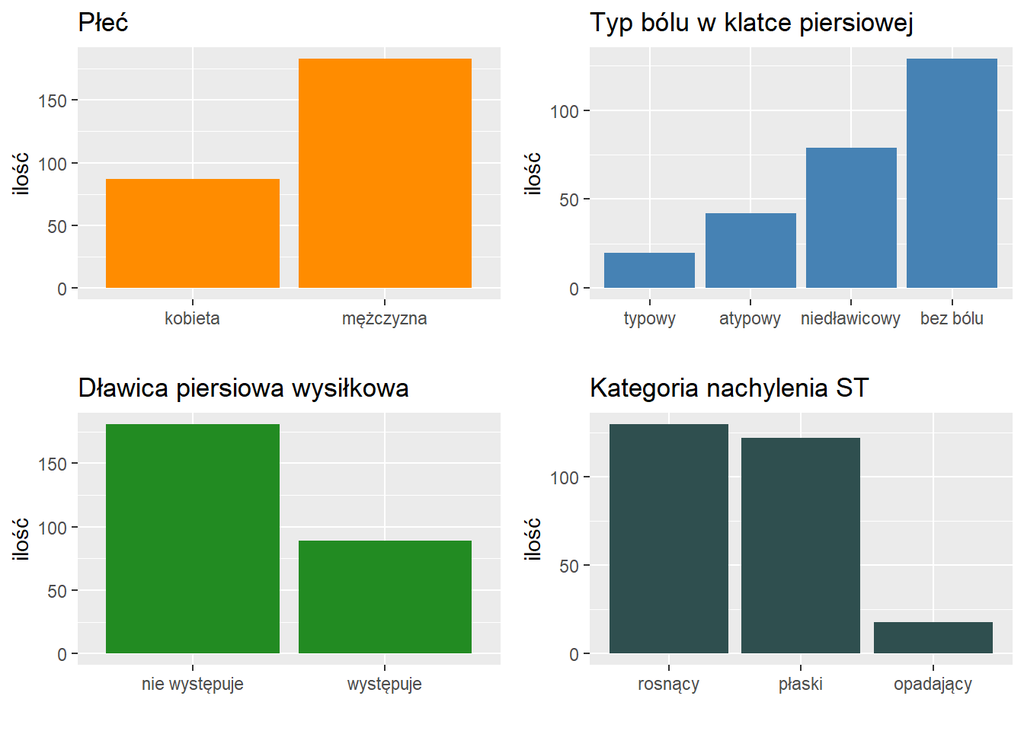

```r
b1 <- ggplot(dane, aes(x=factor(Sex)))+geom_bar(fill="darkorange")+labs(title="Płeć",x="",y="ilość")+scale_x_discrete(labels=c("0"="kobieta","1"="mężczyzna"))

b2 <- ggplot(dane, aes(x=factor(Chest.pain.type)))+geom_bar(fill="steelblue")+labs(title="Typ bólu w klatce piersiowej",x="",y="ilość")+scale_x_discrete(labels=c("1"="typowy","2"="atypowy","3"="niedławicowy","4"="bez bólu"))

b3 <- ggplot(dane, aes(x=factor(Exercise.angina)))+geom_bar(fill="forestgreen")+labs(title="Dławica piersiowa wysiłkowa",x="",y="ilość")+scale_x_discrete(labels=c("0"="nie występuje","1"="występuje"))

b4 <- ggplot(dane, aes(x=factor(Slope.of.ST)))+geom_bar(fill="darkslategray")+labs(title="Kategoria nachylenia ST",x="",y="ilość")+scale_x_discrete(labels=c("1"="rosnący","2"="płaski","3"="opadający"))

b5 <- ggplot(dane, aes(x=factor(Number.of.vessels.fluro)))+geom_bar(fill="lightblue")+labs(title="Liczba głównych naczyń wieńcowych",x="",y="ilość")+scale_x_discrete(labels=c("0"="brak zwężeń","1"="1 naczynie\nz widoczną\nzmianą","2"="2 naczynia\nz widoczną\nzmianą","3"="3 naczynia\nz widoczną\nzmianą"))

b6 <- ggplot(dane, aes(x=factor(Thallium)))+geom_bar(fill="brown")+labs(title="wynik testu obciążeniowego",x="",y="ilość")+scale_x_discrete(labels=c("3"="normalny przepływ","6"="defekt stały","7"="defekt odwracalny"))

b7 <- ggplot(dane, aes(x=factor(EKG.results)))+geom_bar(fill="mediumpurple")+labs(title="Wynik EKG w spoczynku",x="",y="ilość")+scale_x_discrete(labels=c("0"="prawidłowy","1"="nieprawidłowości\nprzerost","2"="inne\nnieprawidłowości"))

b8 <- ggplot(dane, aes(x=factor(FBS.over.120)))+geom_bar(fill="pink")+labs(title="Poziom glukozy na czczo",x="",y="ilość")+scale_x_discrete(labels=c("0"="niski","1"="wysoki"))

grid.arrange(b1,b2,b3,b4,ncol=2)
```

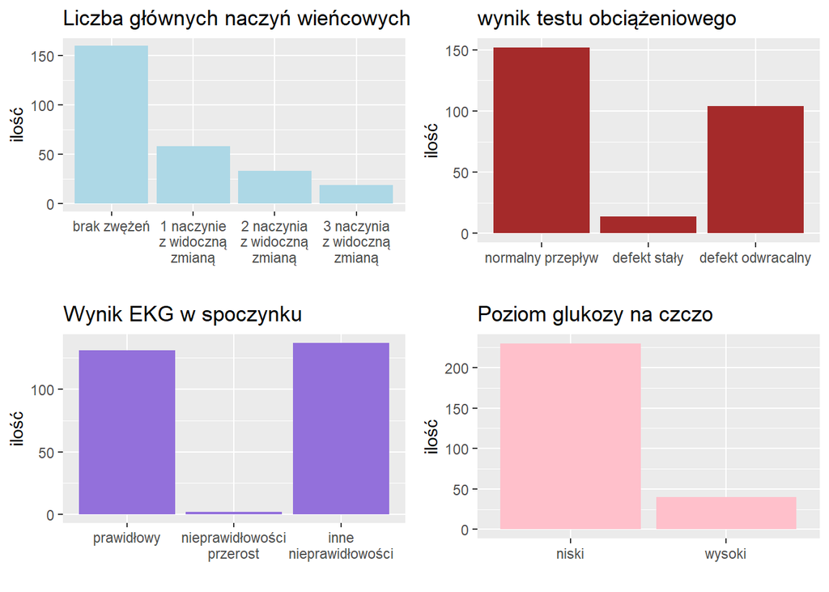

```r
grid.arrange(b5,b6,b7,b8,ncol=2)
```

# `7. Porównanie zmiennych numerycznych względem choroby serca`

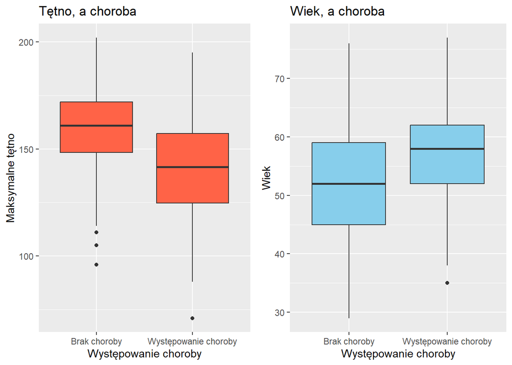

```r
g1<-ggplot(dane, aes(x=Heart.Disease,y=Max.HR))+
  geom_boxplot(fill="tomato")+
  labs(
    title="Tętno, a choroba",
    x="Występowanie choroby",
    y="Maksymalne tętno"
  )+
  scale_x_discrete(labels=c("Absence"="Brak choroby","Presence"="Występowanie choroby"))

g2<-ggplot(dane, aes(x=Heart.Disease,y=Age))+
  geom_boxplot(fill="skyblue")+
  labs(
    title="Wiek, a choroba",
    x="Występowanie choroby",
    y="Wiek"
  )+
  scale_x_discrete(labels=c("Absence"="Brak choroby","Presence"="Występowanie choroby"))

g3<-ggplot(dane, aes(x=Heart.Disease,y=BP))+
  geom_boxplot(fill="darkslategray")+
  labs(
    title="Ciśnienie, a choroba",
    x="Występowanie choroby",
    y="Ciśnienie tętnicze w spoczynku"
  )+
  scale_x_discrete(labels=c("Absence"="Brak choroby","Presence"="Występowanie choroby"))

g4<-ggplot(dane, aes(x=Heart.Disease,y=Cholesterol))+
  geom_boxplot(fill="mediumpurple")+
  labs(
    title="Cholesterol, a choroba",
    x="Występowanie choroby",
    y="Poziom cholesterolu"
  )+
  scale_x_discrete(labels=c("Absence"="Brak choroby","Presence"="Występowanie choroby"))

g5<-ggplot(dane, aes(x=Heart.Disease,y=ST.depression))+
  geom_boxplot(fill="firebrick")+
  labs(
    title="Nachylenie ST, a choroba",
    x="Występowanie choroby",
    y="Wartość nachylenia ST"
  )+
  scale_x_discrete(labels=c("Absence"="Brak choroby","Presence"="Występowanie choroby"))

grid.arrange(g1,g2, ncol=2)
```

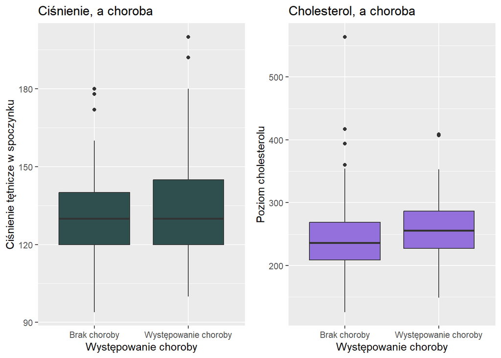

```r
grid.arrange(g3,g4, ncol=2)
```

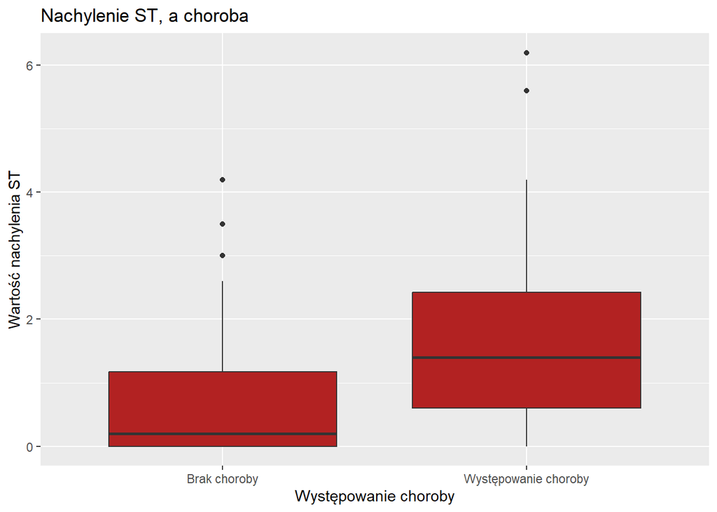

```r
g5
```

# `8. Test Wilcoxa dla zmiennych numerycznych`

```r
t1 <- wilcox.test(Max.HR ~Heart.Disease, dane)
t2 <- wilcox.test(Age ~Heart.Disease, dane)
t3 <- wilcox.test(BP ~Heart.Disease, dane)
t4 <- wilcox.test(Cholesterol ~Heart.Disease, dane)
t5 <- wilcox.test(ST.depression ~Heart.Disease, dane)
tabela_testow <- data.frame(
  zmienna = c("Tętno","Wiek","Ciśnienie","Cholesterol","Nachylenie ST"),
  p_values=c(
    t1$p.value,
    t2$p.value,
    t3$p.value,
    t4$p.value,
    t5$p.value
  )
)
tabela_testow
```

```
##         zmienna     p_values
## 1         Tętno 5.841045e-12
## 2          Wiek 2.051984e-04
## 3     Ciśnienie 3.154067e-02
## 4   Cholesterol 7.700853e-03
## 5 Nachylenie ST 2.979412e-11
```

# `9. Porównanie zmiennych kategorycznych względem choroby serca`

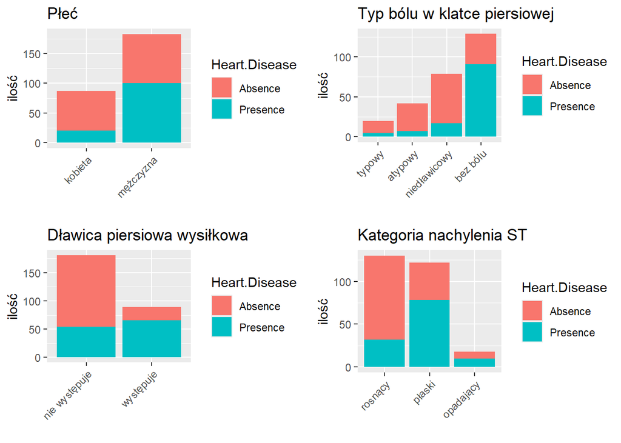

```r
s1 <- ggplot(dane, aes(x=factor(Sex),fill=Heart.Disease))+geom_bar(position="stack")+labs(title="Płeć",x="",y="ilość")+scale_x_discrete(labels=c("0"="kobieta","1"="mężczyzna"))+
  theme(
    axis.text.x = element_text(angle = 45, hjust = 1)
  )

s2 <- ggplot(dane, aes(x=factor(Chest.pain.type),fill=Heart.Disease))+geom_bar(position="stack")+labs(title="Typ bólu w klatce piersiowej",x="",y="ilość")+scale_x_discrete(labels=c("1"="typowy","2"="atypowy","3"="niedławicowy","4"="bez bólu"))+
  theme(
    axis.text.x = element_text(angle = 45, hjust = 1)
  )

s3 <- ggplot(dane, aes(x=factor(Exercise.angina),fill=Heart.Disease))+geom_bar(position="stack")+labs(title="Dławica piersiowa wysiłkowa",x="",y="ilość")+scale_x_discrete(labels=c("0"="nie występuje","1"="występuje"))+
  theme(
    axis.text.x = element_text(angle = 45, hjust = 1)
  )

s4 <- ggplot(dane, aes(x=factor(Slope.of.ST),fill=Heart.Disease))+geom_bar(position="stack")+labs(title="Kategoria nachylenia ST",x="",y="ilość")+scale_x_discrete(labels=c("1"="rosnący","2"="płaski","3"="opadający"))+
  theme(
    axis.text.x = element_text(angle = 45, hjust = 1)
  )

s5 <- ggplot(dane, aes(x=factor(Number.of.vessels.fluro),fill=Heart.Disease))+geom_bar(position="stack")+labs(title="Liczba głównych naczyń wieńcowych",x="",y="ilość")+scale_x_discrete(labels=c("0"="brak zwężeń","1"="1 naczynie z widoczną zmianą","2"="2 naczynia z widoczną zmianą","3"="3 naczynia z widoczną zmianą"))+
  theme(
    axis.text.x = element_text(angle = 45, hjust = 1)
  )

s6 <- ggplot(dane, aes(x=factor(Thallium),fill=Heart.Disease))+geom_bar(position="stack")+labs(title="wynik testu obciążeniowego",x="",y="ilość")+scale_x_discrete(labels=c("3"="normalny przepływ","6"="defekt stały","7"="defekt odwracalny"))+
  theme(
    axis.text.x = element_text(angle = 45, hjust = 1)
  )

s7 <- ggplot(dane, aes(x=factor(EKG.results),fill=Heart.Disease))+geom_bar(position="stack")+labs(title="Wynik EKG w spoczynku",x="",y="ilość")+scale_x_discrete(labels=c("0"="prawidłowy","1"="nieprawidłowości\nprzerost","2"="inne\nnieprawidłowości"))+
  theme(
    axis.text.x = element_text(angle = 45, hjust = 1)
  )

s8 <- ggplot(dane, aes(x=factor(FBS.over.120),fill=Heart.Disease))+geom_bar(position="stack")+labs(title="Poziom glukozy na czczo",x="",y="ilość")+scale_x_discrete(labels=c("0"="niski","1"="wysoki"))+
  theme(
    axis.text.x = element_text(angle = 45, hjust = 1)
  )

grid.arrange(s1,s2,s3,s4,ncol=2)
```

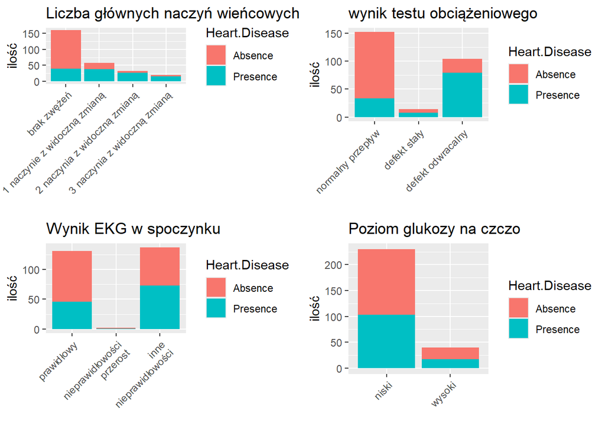

```r
grid.arrange(s5,s6,s7,s8,ncol=2)
```

# `10. Test Spearmana o korelacji między badaniami`

```r
zmienne <-dane[,c("Max.HR","Age","BP","Cholesterol","ST.depression")]
wynik<-rcorr(as.matrix(zmienne),type="spearman")
wynik
```

```
##               Max.HR   Age    BP Cholesterol ST.depression
## Max.HR          1.00 -0.40 -0.04       -0.06         -0.42
## Age            -0.40  1.00  0.28        0.21          0.26
## BP             -0.04  0.28  1.00        0.19          0.18
## Cholesterol    -0.06  0.21  0.19        1.00          0.01
## ST.depression  -0.42  0.26  0.18        0.01          1.00
##
## n= 270
##
##
## P
##               Max.HR Age    BP     Cholesterol ST.depression
## Max.HR               0.0000 0.4823 0.3553      0.0000
## Age           0.0000        0.0000 0.0005      0.0000
## BP            0.4823 0.0000        0.0017      0.0026
## Cholesterol   0.3553 0.0005 0.0017             0.8209
## ST.depression 0.0000 0.0000 0.0026 0.8209
```

Na podstawie wyników testu Spearmana jesteśmy w stanie stwierdzić, że istotnie statystycznie (p<0.05) są wyniki dla par:

- **Tętno** i **Wiek** - p = -0.40 (umiarkowanie silna ujemna korelacja)
- **Tętno** i **Nachylenie ST** - p = -0.42 (umiarkowanie silna ujemna korelacja)
- **Wiek** i **Ciśnienie** - p = 0.28 (umiarkowanie silna dodatnia korelacja)
- **Wiek** i **Cholesterol** - p = 0.21 (słaba dodatnia korelacja)
- **Wiek** i **Nachylenie ST** - p = 0.26 (słaba dodatnia korelacja)
- **Ciśnienie** i **Cholesterol** - p = 0.19 (słaba dodatnia korelacja)
- **Ciśnienie** i **Nachylenie ST** - p = 0.18 (słaba dodatnia korelacja)

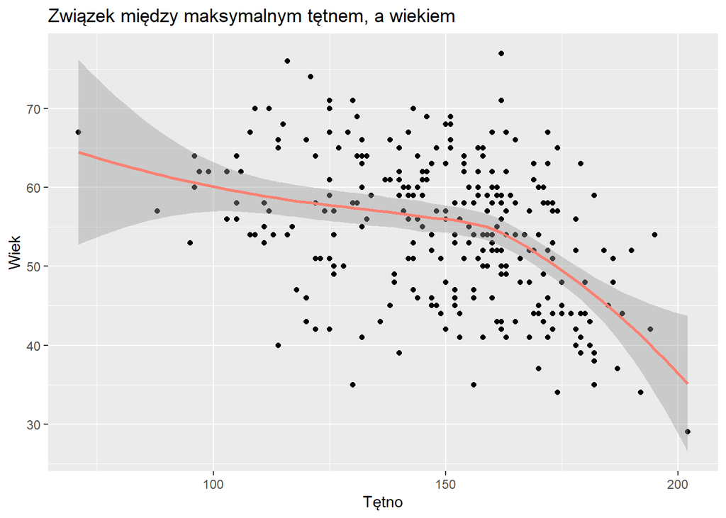

```r
Sp1 <- ggplot(dane, aes(x=Max.HR, y=Age))+
  geom_point()+
  geom_smooth(method = "loess", se=TRUE, color="salmon") +
  labs(
    title="Związek między maksymalnym tętnem, a wiekiem",
    x="Tętno",
    y="Wiek"
  )

Sp2 <- ggplot(dane, aes(x=Max.HR, y=ST.depression))+
  geom_point()+
  geom_smooth(method = "loess", se=TRUE, color="darkorange") +
  labs(
    title="Związek między maksymalnym tętnem, a wartością nachylenia ST",
    x="Tętno",
    y="Nachylenie ST"
  )

Sp3 <- ggplot(dane, aes(x=Age, y=BP))+
  geom_point()+
  geom_smooth(method = "loess", se=TRUE, color="skyblue") +
  labs(
    title="Związek między wiekiem, a ciśnieniem tętniczym",
    x="Wiek",
    y="Ciśnienie"
  )

Sp4 <- ggplot(dane, aes(x=Age, y=Cholesterol))+
  geom_point()+
  geom_smooth(method = "loess", se=TRUE, color="forestgreen") +
  labs(
    title="Związek między wiekiem, a cholesterolem",
    x="Wiek",
    y="Cholesterol"
  )

Sp5 <- ggplot(dane, aes(x=Age, y=ST.depression))+
  geom_point()+
  geom_smooth(method = "loess", se=TRUE, color="darkslategray") +
  labs(
    title="Związek między wiekiem, a wartością nachylenia ST",
    x="Wiek",
    y="Nachylenie ST"
  )

Sp6 <- ggplot(dane, aes(x=Cholesterol, y=BP))+
  geom_point()+
  geom_smooth(method = "loess", se=TRUE, color="steelblue") +
  labs(
    title="Związek między cholesterolem, a ciśnieniem",
    x="Cholesterol",
    y="Ciśnienie tętnicze"
  )

Sp7 <- ggplot(dane, aes(x=BP, y=ST.depression))+
  geom_point()+
  geom_smooth(method = "loess", se=TRUE, color="royalblue") +
  labs(
    title="Związek między ciśnieniem tętniczym, a wartością nachylenia ST",
    x="Ciśnienie",
    y="Nachylenie ST"
  )
Sp1
```

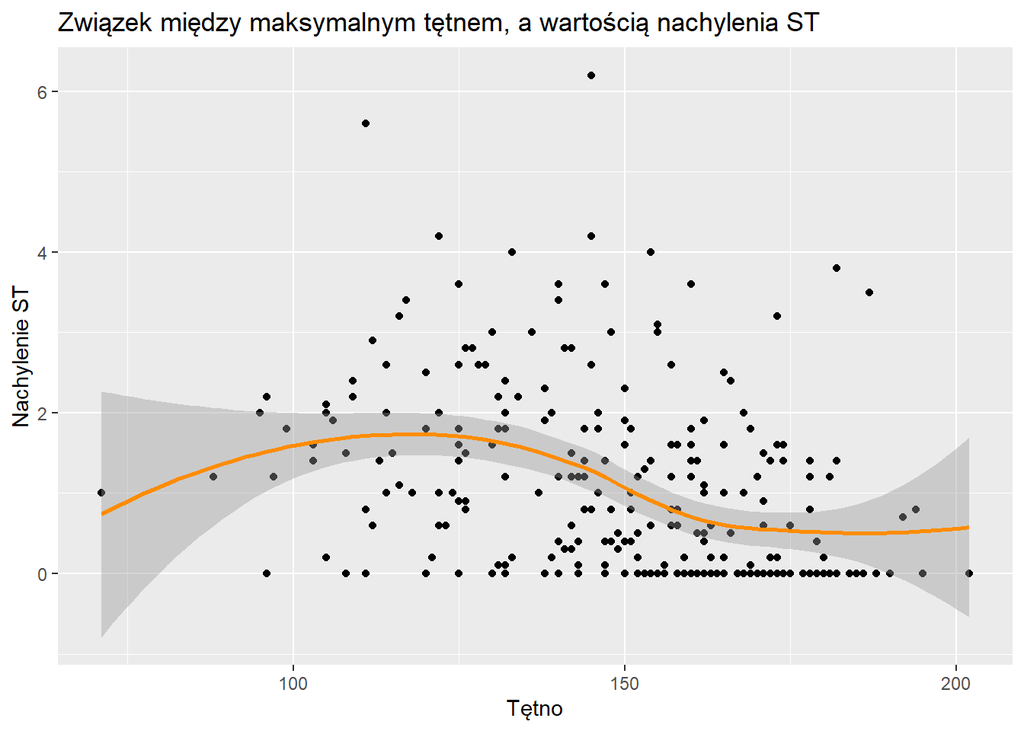

```r
Sp2
```

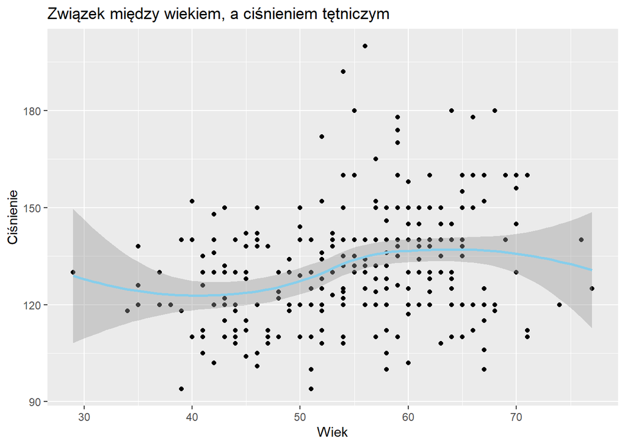

```r
Sp3
```

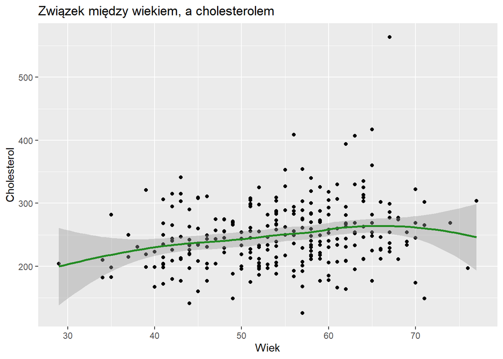

```r
Sp4
```

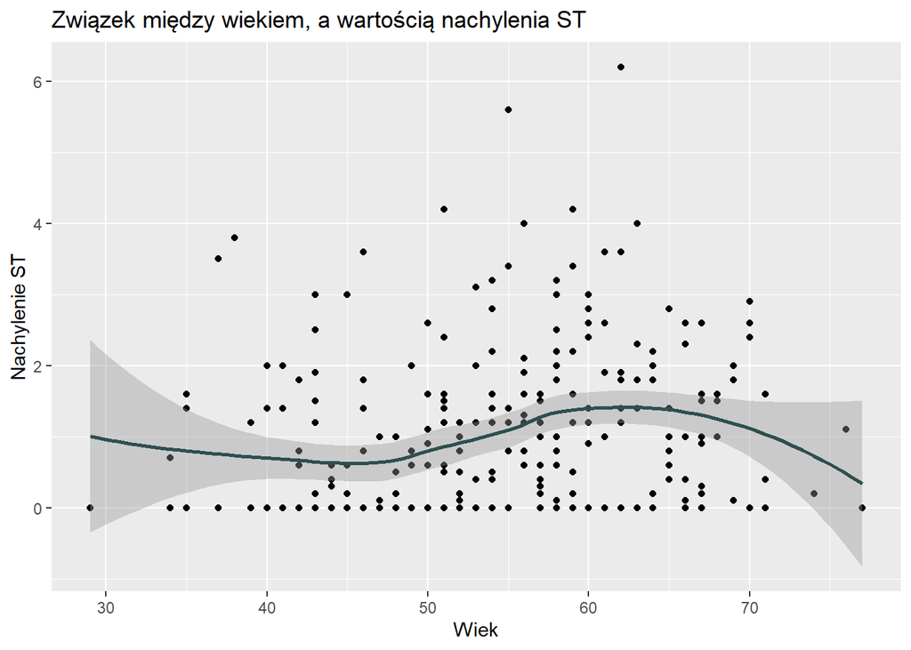

```r
Sp5
```

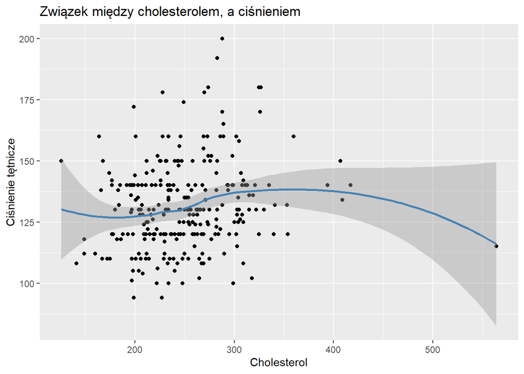

```r
Sp6
```

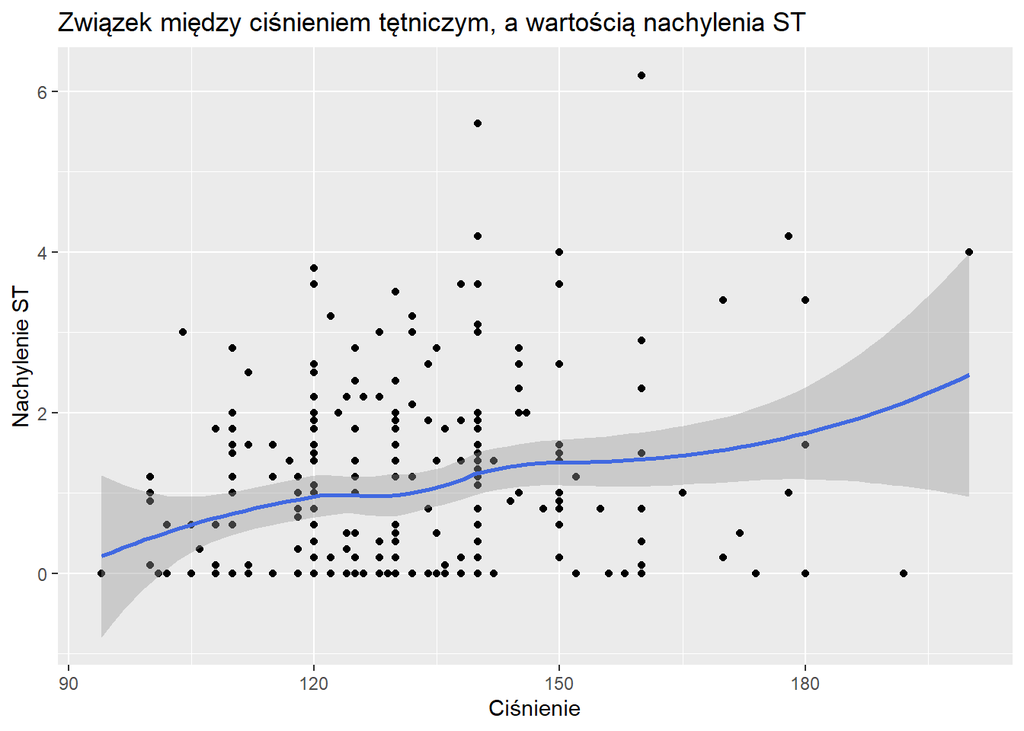

```r
Sp7
```

# `11. Podsumowanie`

Na początku badania zadaliśmy sobie następujące pytania, na które otrzymaliśmy zatysfakcjonujące odpowiedzi:

1. *“Czy istnieje zależność pomiędzy wiekiem oraz płcią pacjentów, a prawdopodobieństwem wystąpienia choroby serca?”*

- **Tak, istnieje znaczące zwiększenie rozwinięcia choroby serca w okolicach wieku 50 lat oraz istnieje zależność pomiędzy płcią, a chorobą (mężczyzni są na nią bardziej podatni)**

2.*“Które badania mają największą korelacje między konkretnymi wynikami a istnieniem choroby serca?”*

-**Zdecydowanie najważniejszymi badaniami w celu rozstrzygnięcie choroby serca jest:**

[output not shown]

**niewiele mniej istotna też jest informacja o:**

```
-wieku (starszy = większe ryzyko)
-poziomie cholesterolu pacjenta (wyższy = większe ryzyko)
```

3. *“Czy istnieje korelacja pomiędzy konkretnymi badaniami?”*

-**Istnieje umiarkowanie silna ujemna/dodatnia korelacja między:**

[output not shown]